# Wikipedia as Data: Page Views and Edit Activity in R

2026-03-12

# Setting Up

```r
source("R//functions//functions.R")
```

```r
package_check(c("jsonlite", "ggplot2", "dplyr", "tidylog",
                "sf", "tmap", "rnaturalearth", "rnaturalearthdata"))
```

# The Wikipedia API

Unlike the Google Trends interface we have worked with elsewhere, Wikipedia provides a **fully official, documented, and free REST API** — no scraping, no session cookies, no rate-limiting for reasonable use. But, as always, this doesn’t mean the code you write today won’t break unexpectedly.

The API is maintained by the Wikimedia Foundation and documented at [wikimedia.org/api/rest_v1](https://wikimedia.org/api/rest_v1/). It provides access to:

- **Page view counts**: how many times a given article was viewed, per day
- **Edit activity**: how many times a given article was edited, per day
- **Top articles**: the most-viewed articles on a given Wikipedia edition
- …and much more

We will access both page views and edit data via custom functions that call the API directly using `{jsonlite}`. The two functions — `get_article_views()` and `get_article_edits()` — are already loaded from `functions.R`, and both work the same way: they construct a URL, call the API, and return a tidy data frame. Reading their code is a good introduction to working with REST APIs in R.

# Interpreting Wikipedia Data

Before diving in, it is worth being clear about what these two metrics actually measure:

**Page views** count the number of times an article page was loaded by a human user (bots are filtered out). A spike in page views typically indicates that something happened — a news event, a speech, a viral moment — that sent people to Wikipedia to find out more.

**Edit counts** count the number of times the article text was changed. Wikipedia articles about ongoing events are edited in near real-time as events unfold — sometimes within minutes of breaking news. High edit activity can indicate:

- New information being added as events develop
- Controversy or disputed facts (leading to “edit wars”)
- Vandalism and its subsequent repair

Both metrics are **raw counts**, not normalised like Google Trends data. If you want to compare across language editions of different sizes, you will need to normalise by total project activity — something we will do in Part 3.

# Part 1: Page Views — Trump Across the Globe

The article “Donald Trump” is one of the most-viewed political articles across virtually all language editions of Wikipedia, and — critically for our purposes — the article title is the same in almost every language. This makes it unusually easy to compare interest across countries.

## Time Series: English Wikipedia

```r
# Set date range (API lags ~1 day, so end at yesterday):
end_date   <- format(Sys.Date() - 1, "%Y%m%d")
start_date <- format(Sys.Date() - 30, "%Y%m%d")

# Define Wikipedia articles based on their URLs:
trump_articles <- c("Donald_Trump",
                    "Second_presidency_of_Donald_Trump",
                    "Relationship_of_Donald_Trump_and_Jeffrey_Epstein")
```

```r
# Fetch daily page views for each article on English Wikipedia:
views_list <- lapply(trump_articles, function(article) {
  tryCatch(
    get_article_views(article = article, project = "en.wikipedia",
                      start = start_date, end = end_date),
    error = function(e) {
      message("Could not fetch views for: ", article, " — ", e$message)
      NULL
    }
  )
})
views_combined <- bind_rows(views_list)

# If the API returned nothing, fall back to pre-fetched data:
if (nrow(views_combined) == 0) {
  views_combined <- .fallback("data/if_needed/wiki_views_combined.rds")
}

str(views_combined)
```

```
## 'data.frame':    90 obs. of  4 variables:
##  $ date   : Date, format: "2026-02-10" "2026-02-11" ...
##  $ views  : int  58028 54059 54284 51054 44314 45289 47726 49260 44869 47989 ...
##  $ article: chr  "Donald_Trump" "Donald_Trump" "Donald_Trump" "Donald_Trump" ...
##  $ project: chr  "en.wikipedia" "en.wikipedia" "en.wikipedia" "en.wikipedia" ...
```

Note the data structure: one row per article per day, with a `views` column giving the raw count. Compare this to Google Trends — there is no 0–100 normalisation here. In this case, we asked for 30 days worth of views for three articles (defined in `trump_articles` above), for a total of 90 observations.

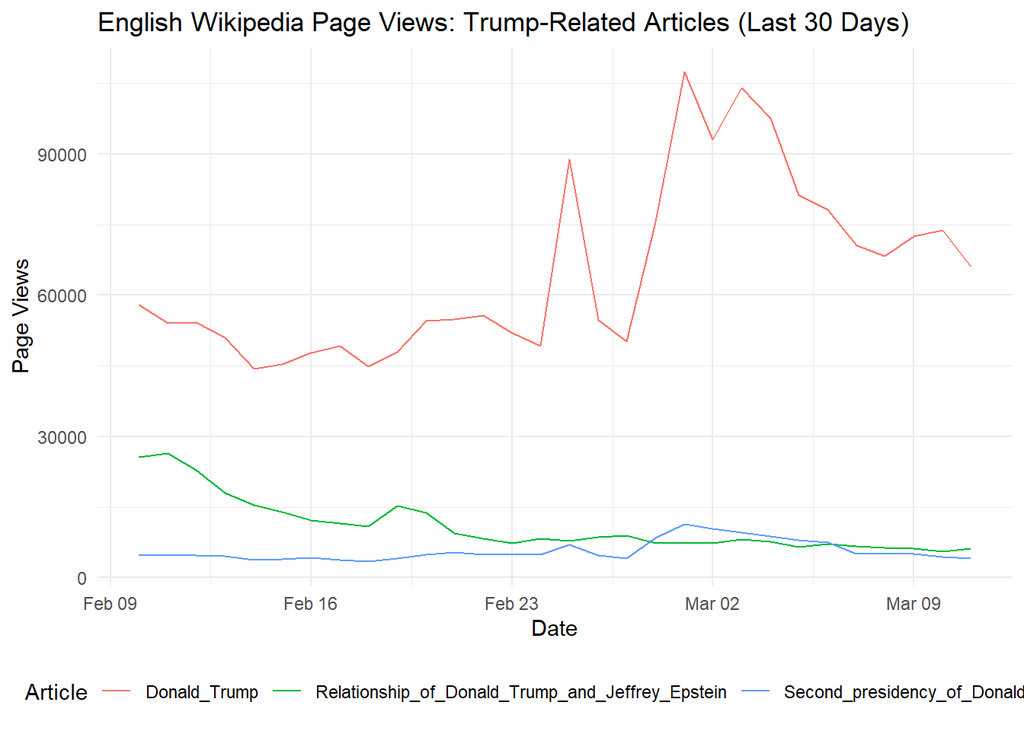

```r
ggplot(views_combined, aes(x = as.Date(date), y = views, colour = article)) +
  geom_line() +
  labs(title = "English Wikipedia Page Views: Trump-Related Articles (Last 30 Days)",
       x = "Date", y = "Page Views", colour = "Article") +
  theme_minimal() +
  theme(legend.position = "bottom")
```

## Cross-National Map: Which Countries Are Reading About Trump?

Wikipedia is published in hundreds of languages, each with its own reader community. By summing page views across language editions and mapping them to their primary country, we get a rough proxy for cross-national interest.

This is an imperfect measure — English Wikipedia is read worldwide, not just in the US — but it is a useful approximation, and its limitations are themselves worth discussing.

```r
# Language editions to query, and their representative countries:
lang_country <- data.frame(
  language = c("en", "de", "fr", "es", "it", "pt", "ru", "zh", "ja",
               "ar", "nl", "pl", "sv", "ko", "tr", "uk", "id", "vi"),
  country  = c("United States of America", "Germany", "France", "Spain", "Italy",
               "Brazil", "Russia", "China", "Japan", "Egypt", "Netherlands",
               "Poland", "Sweden", "South Korea", "Turkey", "Ukraine",
               "Indonesia", "Vietnam"),
  stringsAsFactors = FALSE
)

# Fetch total views per language edition over the last 30 days:
lang_views_list <- lapply(lang_country$language, function(lang) {
  tryCatch({
    result <- get_article_views(article = "Donald_Trump",
                                project = paste0(lang, ".wikipedia"),
                                start   = start_date,
                                end     = end_date)
    data.frame(language = lang, total_views = sum(result$views, na.rm = TRUE))
  }, error = function(e) {
    message("Could not fetch for language: ", lang)
    data.frame(language = lang, total_views = NA_integer_)
  })
})
lang_views_df <- bind_rows(lang_views_list)

# If all language queries failed, fall back to pre-fetched data:
if (all(is.na(lang_views_df$total_views))) {
  lang_views_df <- .fallback("data/if_needed/wiki_lang_views_df.rds")
}

# Join to country lookup, then to shapefile:
lang_views_df <- left_join(lang_views_df, lang_country, by = "language")
```

```
## left_join: added one column (country)
##            > rows only in lang_views_df   0
##            > rows only in lang_country  ( 0)
##            > matched rows                18
##            >                            ====
##            > rows total                  18
```

```r
country_shp   <- st_read("data/shapefiles/world-administrative-boundaries.shp", quiet = TRUE)
map_views     <- left_join(country_shp, lang_views_df, by = c("name" = "country"))
```

```
## left_join: added 2 columns (language, total_views)
##            > rows only in country_shp    240
##            > rows only in lang_views_df (  2)
##            > matched rows                 16
##            >                            =====
##            > rows total                  256
```

```r
# Inspect the join:
cat("Matched countries:", sum(!is.na(map_views$total_views)), "\n")
```

```
## Matched countries: 16
```

```
## ── tmap v3 code detected ───────────────────────────────────────────────────────
```

[output not shown]

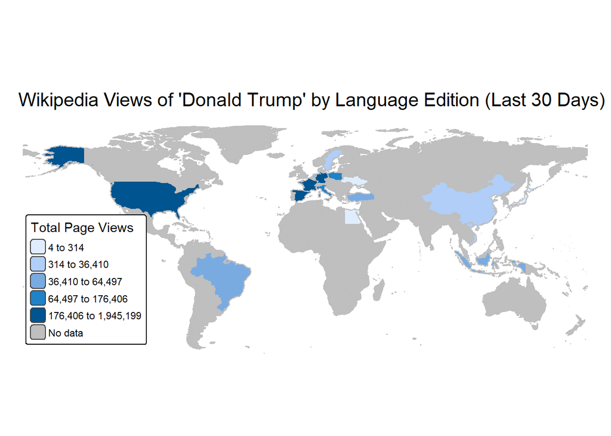

```r
tm_shape(map_views) +
  tm_fill(col      = "total_views",
          style    = "quantile",
          n        = 5,
          title    = "Total Page Views",
          textNA   = "No data") +
  tm_borders(col = "gray") +
  tm_layout(main.title      = "Wikipedia Views of 'Donald Trump' by Language Edition (Last 30 Days)",
            legend.position = c("left", "bottom"),
            frame           = FALSE)
```

# Part 2: Edit Activity — Wikipedia as a Real-Time Record

If page views measure *reading*, edit counts measure *writing*. Every change made to a Wikipedia article is recorded — who made it, when, and what changed. For high-profile topics, this creates a rich time series of editorial activity that closely tracks real-world events.

The “Donald Trump” article on English Wikipedia is one of the most-edited political articles in Wikipedia’s history. Plotting daily edit counts reveals clear spikes around major events: court appearances, elections, executive orders, and controversies. This kind of analysis — linking edit surges to real-world moments — is an active area of research using Wikipedia as a data source.

## Time Series: Daily Edits on English Wikipedia

```r
trump_edits_en <- tryCatch(
  get_article_edits(
    article = "Donald_Trump",
    project = "en.wikipedia",
    start   = "2024-01-01",
    end     = format(Sys.Date() - 1, "%Y-%m-%d")
  ),
  error = function(e) {
    message("Could not fetch edit data: ", e$message)
    .fallback("data/if_needed/wiki_trump_edits_en.rds")
  }
)

if (!is.null(trump_edits_en)) str(trump_edits_en)
```

```
## 'data.frame':    742 obs. of  4 variables:
##  $ date   : Date, format: "2024-01-01" "2024-01-02" ...
##  $ edits  : int  3 4 4 5 4 3 3 2 4 8 ...
##  $ article: chr  "Donald_Trump" "Donald_Trump" "Donald_Trump" "Donald_Trump" ...
##  $ project: chr  "en.wikipedia" "en.wikipedia" "en.wikipedia" "en.wikipedia" ...
```

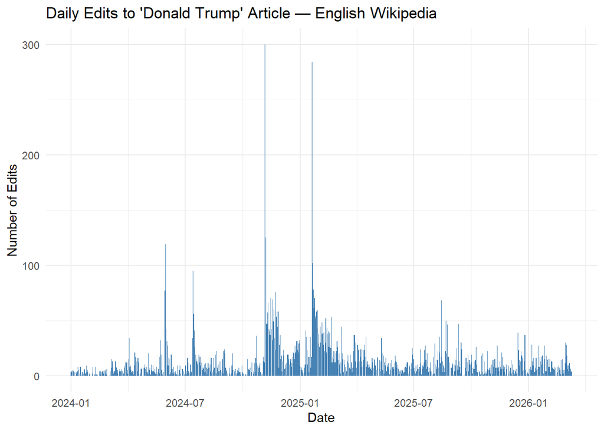

```r
if (!is.null(trump_edits_en)) {
  ggplot(trump_edits_en, aes(x = date, y = edits)) +
    geom_col(fill = "steelblue") +
    labs(title = "Daily Edits to 'Donald Trump' Article — English Wikipedia",
         x = "Date", y = "Number of Edits") +
    theme_minimal()
}
```

Look for spikes. Can you match them to specific events? Cross-reference with a news timeline and see how quickly Wikipedia editing responds to breaking news.

## Cross-National Comparison: Who Is Writing About Trump?

```r
trump_edits_list <- lapply(lang_country$language, function(lang) {
  tryCatch(
    get_article_edits(
      article = "Donald_Trump",
      project = paste0(lang, ".wikipedia"),
      start   = "2024-01-01",
      end     = format(Sys.Date() - 1, "%Y-%m-%d")
    ) %>% mutate(language = lang),
    error = function(e) {
      message("Could not fetch edits for language '", lang, "': ", e$message)
      NULL
    }
  )
})
```

[output not shown]

```r
trump_edits_df <- bind_rows(trump_edits_list)

# If the API returned nothing, fall back to pre-fetched data:
if (nrow(trump_edits_df) == 0) {
  trump_edits_df <- .fallback("data/if_needed/wiki_trump_edits_df.rds")
}
```

[output not shown]

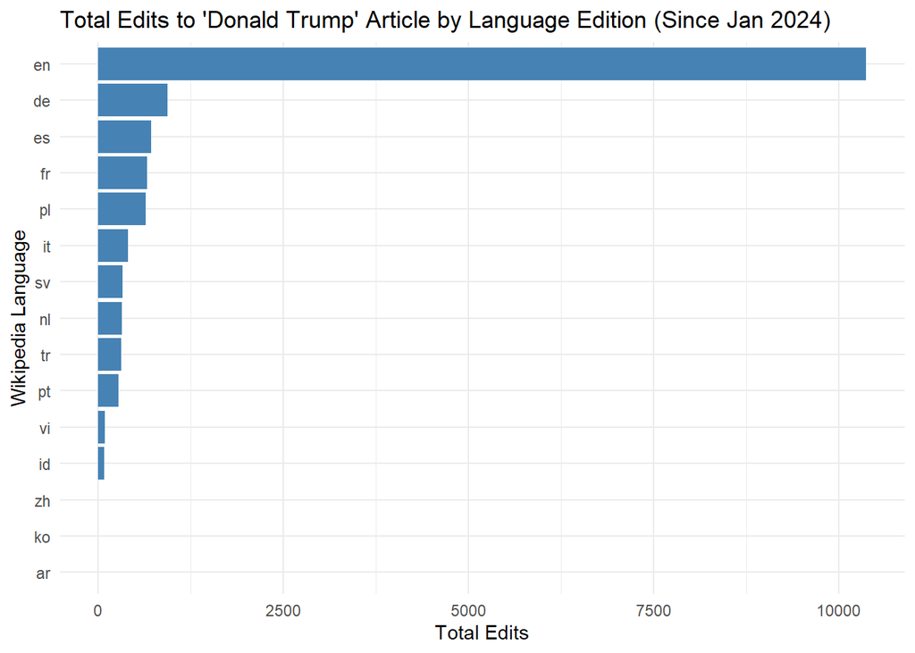

```r
if (nrow(trump_edits_df) > 0) {
  trump_edits_df %>%
    group_by(language) %>%
    summarise(total_edits = sum(edits, na.rm = TRUE), .groups = "drop") %>%
    arrange(desc(total_edits)) %>%
    ggplot(aes(x = reorder(language, total_edits), y = total_edits)) +
    geom_col(fill = "steelblue") +
    coord_flip() +
    labs(title = "Total Edits to 'Donald Trump' Article by Language Edition (Since Jan 2024)",
         x = "Wikipedia Language", y = "Total Edits") +
    theme_minimal()
}
```

[output not shown]

[figure not shown]

```r
if (nrow(trump_edits_df) > 0) {
  lang_edits_totals <- trump_edits_df %>%
    group_by(language) %>%
    summarise(total_edits = sum(edits, na.rm = TRUE), .groups = "drop") %>%
    left_join(lang_country, by = "language")

  map_edits <- left_join(country_shp, lang_edits_totals, by = c("name" = "country"))

  tm_shape(map_edits) +
    tm_fill(col      = "total_edits",
            style    = "quantile",
            n        = 5,
            title    = "Total Edits",
            textNA   = "No data") +
    tm_borders(col = "gray") +
    tm_layout(main.title      = "Wikipedia Edit Activity on 'Donald Trump' Article by Language Edition",
              legend.position = c("left", "bottom"),
              frame           = FALSE)
}
```

# Part 3: Extension — Normalising the Data

## The Problem with Raw Counts

The maps in Parts 1 and 2 tell us how many times each language edition’s readers viewed or editors changed the Trump article. But this conflates two things:

1. **Relative interest in Trump** within a given Wikipedia community
2. **The overall size of that Wikipedia edition**

English Wikipedia is read by hundreds of millions of people worldwide; Vietnamese Wikipedia is much smaller. Even if Vietnamese readers were proportionally *more* interested in Trump, English Wikipedia would almost certainly show higher raw view counts. Raw counts tell us about absolute volume, not relative attention.

**Normalising** divides each article’s count by the total activity on that edition, giving us something closer to “what share of this edition’s readers were looking at Trump?” This is a more meaningful cross-national comparison.

## Fetching Total Project Views

The `get_project_views()` function (loaded from `functions.R`) calls the Wikimedia aggregate pageviews endpoint — the project-level counterpart to `get_article_views()`. It returns total human pageviews for an entire Wikipedia edition per day. We sum this over the same 30-day window used above to get a denominator for normalisation.

```r
project_views_list <- lapply(lang_country$language, function(lang) {
  Sys.sleep(0.25)
  tryCatch({
    pv <- get_project_views(project = paste0(lang, ".wikipedia"),
                            start   = start_date,
                            end     = end_date)
    data.frame(language = lang,
               total_project_views = sum(pv$views, na.rm = TRUE))
  }, error = function(e) {
    message("Could not fetch project views for: ", lang, " — ", e$message)
    data.frame(language = lang, total_project_views = NA_integer_)
  })
})
project_views_df <- bind_rows(project_views_list)

# If all queries failed, fall back to pre-fetched data:
if (all(is.na(project_views_df$total_project_views))) {
  project_views_df <- .fallback("data/if_needed/wiki_project_views_df.rds")
}

print(project_views_df)
```

```
##    language total_project_views
## 1        en          6882564551
## 2        de           701293292
## 3        fr           609683517
## 4        es           528394237
## 5        it           389235103
## 6        pt           180568117
## 7        ru           658543079
## 8        zh           352121141
## 9        ja           853554701
## 10       ar           106333538
## 11       nl            98132642
## 12       pl           185737430
## 13       sv            64336526
## 14       ko            58015817
## 15       tr           110357232
## 16       uk            58758541
## 17       id            62441065
## 18       vi            46258262
```

## Normalising Page Views

We express normalised views as **Trump article views per 1,000 total project views** — i.e., out of every 1,000 pages a reader viewed on that Wikipedia edition, how many were the Trump article?

```r
# Join Trump article views with total project views, then normalise:
norm_views_df <- lang_views_df %>%
  left_join(project_views_df, by = "language") %>%
  mutate(
    views_per_1k = total_views / total_project_views * 1000
  )
```

```
## left_join: added one column (total_project_views)
##            > rows only in x                  0
##            > rows only in project_views_df ( 0)
##            > matched rows                   18
##            >                               ====
##            > rows total                     18
## mutate: new variable 'views_per_1k' (double) with 18 unique values and 0% NA
```

```r
# Show the comparison: raw vs normalised
norm_views_df %>%
  select(language, country, total_views, total_project_views, views_per_1k) %>%
  arrange(desc(views_per_1k))
```

```
## select: columns reordered (language, country, total_views, total_project_views,
## views_per_1k)
```

```
##    language                  country total_views total_project_views
## 1        vi                  Vietnam       27667            46258262
## 2        id                Indonesia       36435            62441065
## 3        pl                   Poland       88985           185737430
## 4        es                    Spain      248486           528394237
## 5        tr                   Turkey       49582           110357232
## 6        nl              Netherlands       36410            98132642
## 7        pt                   Brazil       64497           180568117
## 8        sv                   Sweden       22394            64336526
## 9        fr                   France      199638           609683517
## 10       it                    Italy      119998           389235103
## 11       en United States of America     1945199          6882564551
## 12       de                  Germany      176406           701293292
## 13       zh                    China         314           352121141
## 14       ko              South Korea           7            58015817
```

[output cut: 23 more lines]

```r
map_norm_views <- left_join(country_shp, norm_views_df, by = c("name" = "country"))
```

```
## left_join: added 4 columns (language, total_views, total_project_views, views_per_1k)
##            > rows only in country_shp    240
##            > rows only in norm_views_df (  2)
##            > matched rows                 16
##            >                            =====
##            > rows total                  256
```

[output not shown]

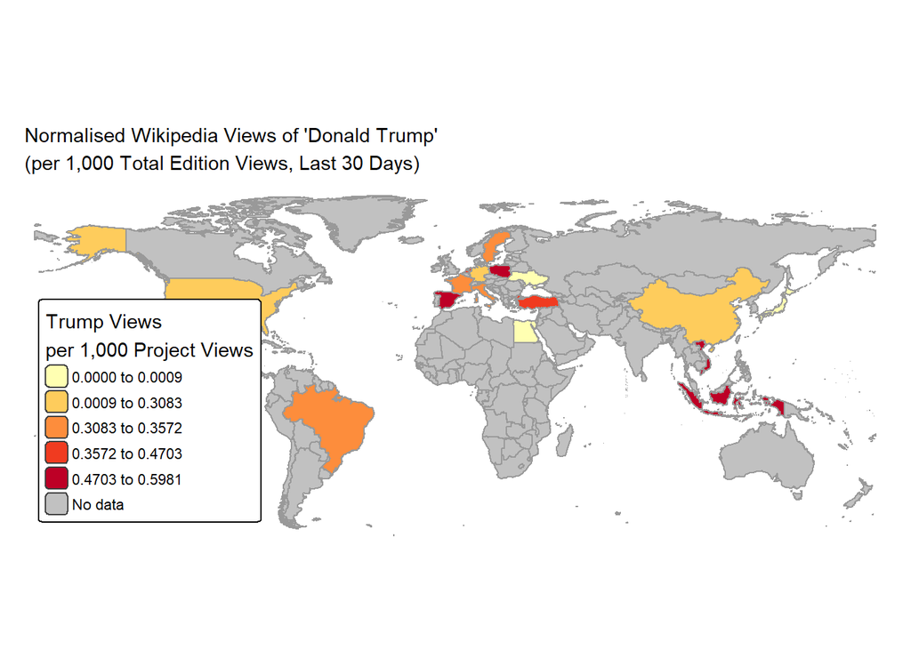

```r
tm_shape(map_norm_views) +
  tm_fill(col      = "views_per_1k",
          style    = "quantile",
          n        = 5,
          title    = "Trump Views\nper 1,000 Project Views",
          textNA   = "No data",
          palette  = "YlOrRd") +
  tm_borders(col = "gray60") +
  tm_layout(
    main.title      = "Normalised Wikipedia Views of 'Donald Trump'\n(per 1,000 Total Edition Views, Last 30 Days)",
    main.title.size = 0.9,
    legend.position = c("left", "bottom"),
    frame           = FALSE
  )
```

Compare this map to the raw-count map in Part 1. What changes? Does the US look different relative to other countries? Are there any surprises — countries with high *relative* interest that were hidden by their edition’s small size?

## Normalising Edit Counts

We apply the same logic to edit counts. Here we normalise edits by total project views (not project edits) — this uses total readership as a proxy for edition size, which is a reasonable denominator when project-wide edit data is not readily available.

```r
if (nrow(trump_edits_df) > 0) {
  lang_edits_totals <- trump_edits_df %>%
    group_by(language) %>%
    summarise(total_edits = sum(edits, na.rm = TRUE), .groups = "drop") %>%
    left_join(lang_country, by = "language")

  norm_edits_df <- lang_edits_totals %>%
    left_join(project_views_df, by = "language") %>%
    mutate(
      edits_per_million_views = total_edits / total_project_views * 1e6
    )

  norm_edits_df %>%
    select(language, country, total_edits, total_project_views, edits_per_million_views) %>%
    arrange(desc(edits_per_million_views))
}
```

```
## group_by: one grouping variable (language)
## summarise: now 15 rows and 2 columns, ungrouped
## left_join: added one column (country)
##            > rows only in x              0
##            > rows only in lang_country ( 3)
##            > matched rows               15
##            >                           ====
##            > rows total                 15
## left_join: added one column (total_project_views)
##            > rows only in x                  0
##            > rows only in project_views_df ( 3)
##            > matched rows                   15
##            >                               ====
##            > rows total                     15
## mutate: new variable 'edits_per_million_views' (double) with 15 unique values and 0% NA
## select: columns reordered (language, country, total_edits, total_project_views, edits_per_million_views)
```

```
## # A tibble: 15 × 5
##    language country       total_edits total_project_views edits_per_million_vi…¹
##    <chr>    <chr>               <int>               <dbl>                  <dbl>
##  1 sv       Sweden                335            64336526                5.21
##  2 pl       Poland                641           185737430                3.45
##  3 nl       Netherlands           323            98132642                3.29
##  4 tr       Turkey                312           110357232                2.83
##  5 vi       Vietnam                90            46258262                1.95
##  6 en       United State…       10371          6882564551                1.51
##  7 pt       Brazil                272           180568117                1.51
##  8 id       Indonesia              87            62441065                1.39
##  9 es       Spain                 721           528394237                1.36
## 10 de       Germany               941           701293292                1.34
## 11 fr       France                660           609683517                1.08
## 12 it       Italy                 401           389235103                1.03
## 13 ko       South Korea             1            58015817                0.0172
## 14 ar       Egypt                   1           106333538                0.00940
## 15 zh       China                   1           352121141                0.00284
## # ℹ abbreviated name: ¹edits_per_million_views
```

[output not shown]

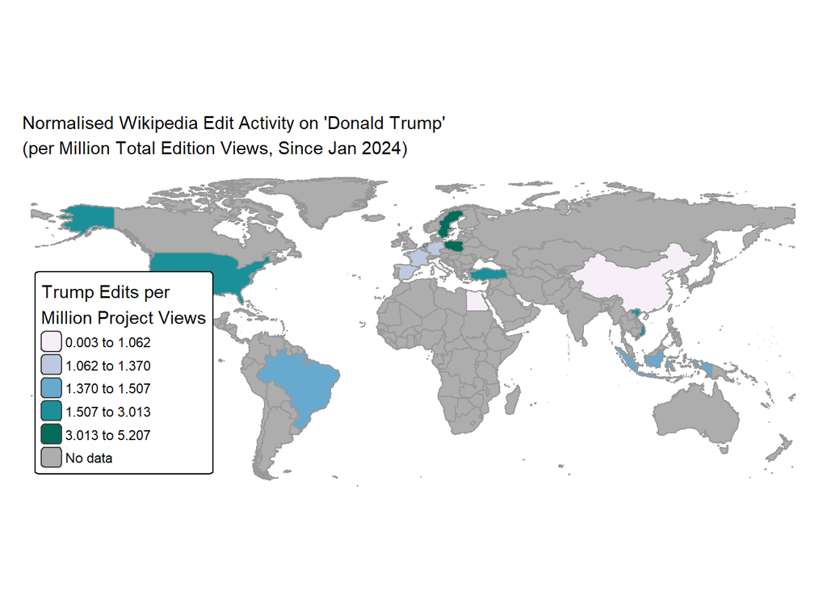

```r
if (exists("norm_edits_df") && nrow(norm_edits_df) > 0) {
  map_norm_edits <- left_join(country_shp, norm_edits_df, by = c("name" = "country"))

  tm_shape(map_norm_edits) +
    tm_fill(col      = "edits_per_million_views",
            style    = "quantile",
            n        = 5,
            title    = "Trump Edits per\nMillion Project Views",
            textNA   = "No data",
            palette  = "PuBuGn") +
    tm_borders(col = "gray60") +
    tm_layout(
      main.title      = "Normalised Wikipedia Edit Activity on 'Donald Trump'\n(per Million Total Edition Views, Since Jan 2024)",
      main.title.size = 0.9,
      legend.position = c("left", "bottom"),
      frame           = FALSE
    )
}
```

Note a **persistent limitation**: even after normalisation, language does not map neatly to country. French Wikipedia is read in France, Belgium, Switzerland, Canada, and across Francophone Africa.

# Independent Task

Pick **one or two Wikipedia articles** on a topic or event that interests you and use `get_article_views()` to plot their daily page view time series.

Some starting points:

- **A current news story** — find the Wikipedia article for a recent event and look for spikes. Do views surge the moment news breaks, or with a delay? How quickly do they fall off?
- **Two sides of a story** — compare views for two related articles (e.g., a policy and its main opponent, or a conflict and its political resolution). Do they move together, or does one lag the other?
- **A recurring event** — something with a predictable schedule (an election, a sporting event, a TV series). Does the pattern in the data match what you would expect?

For any article on English Wikipedia, the URL gives you the article name directly: `https://en.wikipedia.org/wiki/ARTICLE_NAME`. Pass that name to `get_article_views()`, replacing spaces with underscores.